# Area Accurate Venn Diagram

McCade Pearson

2025-06-20

## The Problem with Traditional Venn Diagrams

Most Venn diagrams lie to you. They show categorical relationships but completely ignore the actual magnitude of those relationships. When analyzing player combinations, team performance, or any quantitative overlap, traditional Venn diagrams can be misleading—making small overlaps appear massive and large overlaps seem insignificant.

**This project solves that problem by creating area-accurate Venn diagrams where circle sizes and overlap areas are mathematically proportional to the actual data values.**

## Why Area Accuracy Matters in Analytics

In sports analytics—and business analytics more broadly—proportional representation is crucial for decision-making. Consider these scenarios:

- **Roster Construction**: Understanding the true impact of player combinations
- **Resource Allocation**: Visualizing where investments overlap and where gaps exist
- **Performance Analysis**: Seeing the actual magnitude of synergistic effects

Traditional visualizations can mislead stakeholders about these relationships. Area-accurate diagrams provide immediate, intuitive understanding of both individual contributions and collaborative effects.

## Technical Implementation

The mathematical challenge lies in determining the optimal distance between two circles to achieve a specific overlap area. This requires solving circle-circle intersection equations iteratively.

## Analysis 1: Utah Hockey Club’s Dynamic Duo

The Utah Hockey Club’s emergence as a competitive franchise depends heavily on key player combinations. By analyzing goal involvement data, we can identify which partnerships drive offensive success.

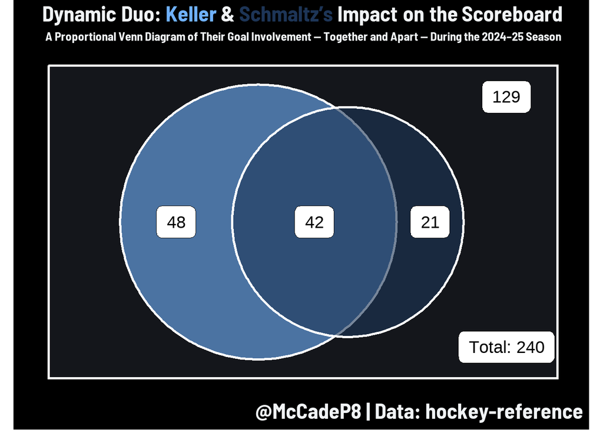

```r
UHC_GoalScorers <- read.csv("UHC_GoalScorers.csv")

TopPair <- UHC_GoalScorers %>%
  mutate(Goal = row_number()) %>%
  rowwise() %>%
  mutate(pair_list = list(combn(na.omit(c(Scorer, Assist1, Assist2)), 2, simplify = FALSE))) %>%
  unnest(pair_list) %>%
  mutate(pair = map_chr(pair_list, ~ paste(sort(.x), collapse = " & "))) %>%
  ungroup() %>%
  count(pair, sort = TRUE) %>%
  head(1)

AB <- 42
A <- 63
B <- 90
nAB <- 240
A2 <- A-AB
B2 <- B-AB
ARadius <- sqrt(A/pi)
BRadius <- sqrt(B/pi)
nAB1 <- nAB/1.616
nAB1 <- sqrt(nAB1)
nAB2 <- nAB1*1.616

D <- findDistance(ARadius, BRadius, AB, eta = 0.0001)
D <- D/2

Point1 <- nAB2/2-D-BRadius
Point2 <- nAB2/2+D-ARadius
Point3 <- nAB2/2-D+BRadius
Point4 <- nAB2/2+D+ARadius
L1 <- (Point1+Point2)/2
L2 <- (Point3+Point4)/2
Z <- (Point2+Point3)/2

ggplot() +
  geom_rect(aes(xmin = 0, xmax = nAB2, ymin = 0, ymax = nAB1), color = "white", fill = "#1C1F26", alpha = 0.7, size = 1) +
  geom_label(aes(x = nAB2*0.90, y = nAB1*0.90, label = nAB-A-B+AB), size = 10) +
  geom_circle(aes(x0 = nAB2/2-D, y0 = nAB1/2, r = BRadius), color = "white", fill = "#6FB1FC", size = 1, alpha = 0.6) +
  geom_circle(aes(x0 = nAB2/2+D, y0 = nAB1/2, r = ARadius), color = "white", fill = "#1D3557", size = 1, alpha = 0.6) +
  geom_label(aes(x = L1, y = nAB1/2, label = B2), size = 10) +
  geom_label(aes(x = L2, y = nAB1/2, label = A2), size = 10) +
  geom_label(aes(x = Z, y = nAB1/2, label = AB), size = 10) +
  geom_label(aes(x = nAB2*0.90, y = nAB1*0.10, label = paste("Total:",nAB)), size = 10) +
  theme(aspect.ratio = 0.616) +
  theme_McCadeP8() +
  theme(aspect.ratio = 0.616,
        panel.background = element_rect(fill = "black"),
        plot.background = element_rect(fill = "black"),
        panel.grid = element_blank(),
        panel.grid.major = element_blank(),
        panel.grid.minor = element_blank(),
        axis.line = element_blank(),
        axis.text = element_blank(),
        axis.ticks = element_blank(),
        axis.title = element_blank(),
        panel.border = element_blank(),
        legend.position = "none",
        plot.subtitle = element_text(face = "bold", size = 20, hjust = 0.5),
        plot.title = element_markdown(face = "bold", size = 36, hjust = 0.5),
        plot.caption = element_text(size = 36)) +
labs(title = "Dynamic Duo: <span style='color:#6FB1FC'>Keller</span> & <span style='color:#1D3557'>Schmaltz's</span> Impact on the Scoreboard",
     subtitle = "A Proportional Venn Diagram of Their Goal Involvement — Together and Apart — During the 2024–25 Season",
     caption = "@McCadeP8 | Data: hockey-reference")
```

**Business Impact**: This analysis helps coaching staff understand optimal line combinations and can inform contract negotiations by quantifying collaborative value versus individual contribution.

## Analysis 2: Utah Jazz Frontcourt Analytics

NBA success increasingly depends on two-man game effectiveness. By analyzing net rating data for Walker Kessler and Lauri Markkanen, we can assess their synergistic impact on team performance.

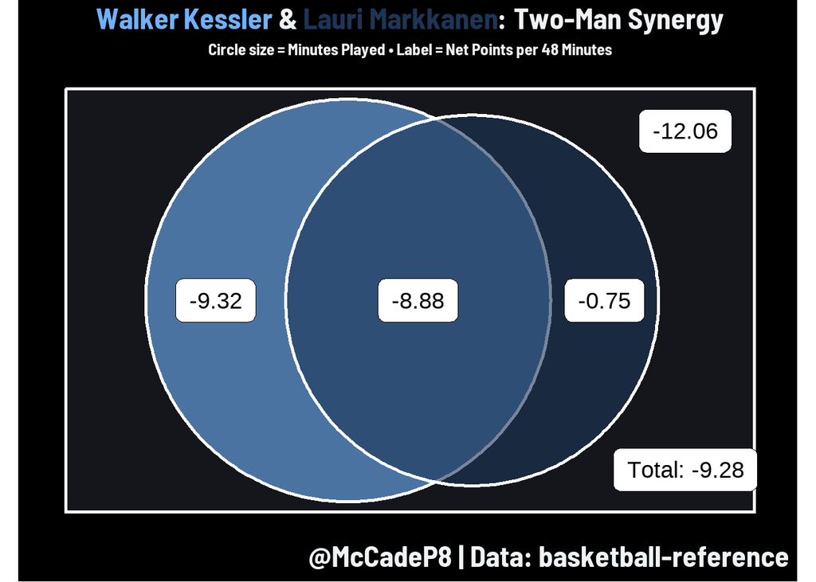

```r
AB <- 962
A <- 1476
B <- 1740
nAB <- 3961
A2 <- A-AB
B2 <- B-AB
ARadius <- sqrt(A/pi)
BRadius <- sqrt(B/pi)
nAB1 <- nAB/1.616
nAB1 <- sqrt(nAB1)
nAB2 <- nAB1*1.616

D <- findDistance(ARadius, BRadius, AB, eta = 0.0001)
D <- D/2

Point1 <- nAB2/2-D-BRadius
Point2 <- nAB2/2+D-ARadius
Point3 <- nAB2/2-D+BRadius
Point4 <- nAB2/2+D+ARadius
L1 <- (Point1+Point2)/2
L2 <- (Point3+Point4)/2
Z <- (Point2+Point3)/2

ggplot() +
  geom_rect(aes(xmin = 0, xmax = nAB2, ymin = 0, ymax = nAB1), color = "white", fill = "#1C1F26", alpha = 0.7, size = 1) +
  geom_label(aes(x = nAB2*0.90, y = nAB1*0.90, label = round((-429/(nAB-A-B+AB)*48),2)), size = 10) +
  geom_circle(aes(x0 = nAB2/2-D, y0 = nAB1/2, r = BRadius), color = "white", fill = "#6FB1FC", size = 1, alpha = 0.6) +
  geom_circle(aes(x0 = nAB2/2+D, y0 = nAB1/2, r = ARadius), color = "white", fill = "#1D3557", size = 1, alpha = 0.6) +
  geom_label(aes(x = L1, y = nAB1/2, label = round((-151/B2*48),2)), size = 10) +
  geom_label(aes(x = L2, y = nAB1/2, label = round((-8/A2*48),2)), size = 10) +
  geom_label(aes(x = Z, y = nAB1/2, label = round((-178/AB*48),2)), size = 10) +
  geom_label(aes(x = nAB2*0.90, y = nAB1*0.10, label = paste("Total:",-9.28)), size = 10) +
  theme(aspect.ratio = 0.616) +
  theme_McCadeP8() +
  theme(aspect.ratio = 0.616,
        panel.background = element_rect(fill = "black"),
        plot.background = element_rect(fill = "black"),
        panel.grid = element_blank(),
        panel.grid.major = element_blank(),
        panel.grid.minor = element_blank(),
        axis.line = element_blank(),
        axis.text = element_blank(),
        axis.ticks = element_blank(),
        axis.title = element_blank(),
        panel.border = element_blank(),
        legend.position = "none",
        plot.subtitle = element_text(face = "bold", size = 20, hjust = 0.5),
        plot.title = element_markdown(face = "bold", size = 36, hjust = 0.5),
        plot.caption = element_text(size = 36)) +
labs(  title = "<span style='color:#6FB1FC'>Walker Kessler</span> & <span style='color:#1D3557'>Lauri Markkanen</span>: Two-Man Synergy",
  subtitle = "Circle size = Minutes Played • Label = Net Points per 48 Minutes",
  caption = "@McCadeP8 | Data: basketball-reference")
```

## Analysis 3: Golf’s Greatest Rivalry

Tiger Woods versus Phil Mickelson represents one of sports’ most compelling rivalries. By examining their major championship top-10 finishes from 1996-2015, we can quantify their competitive balance during golf’s modern era.

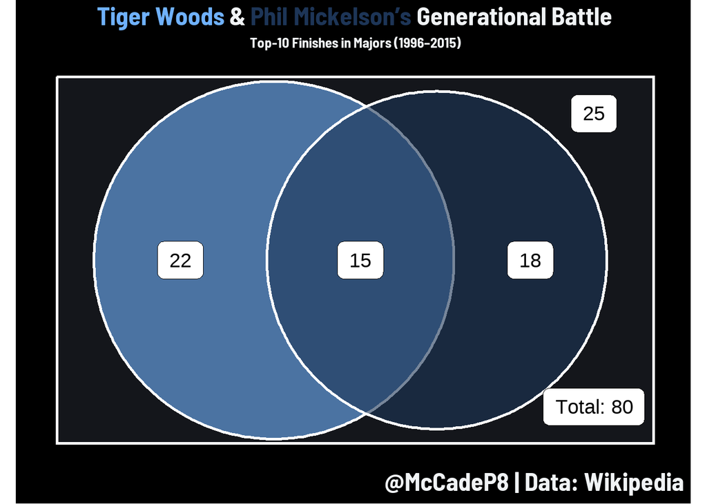

```r
AB <- 15
A <- 33
B <- 37
nAB <- 80
A2 <- A-AB
B2 <- B-AB
ARadius <- sqrt(A/pi)
BRadius <- sqrt(B/pi)
nAB1 <- nAB/1.616
nAB1 <- sqrt(nAB1)
nAB2 <- nAB1*1.616

D <- findDistance(ARadius, BRadius, AB, eta = 0.0001)
D <- D/2

Point1 <- nAB2/2-D-BRadius
Point2 <- nAB2/2+D-ARadius
Point3 <- nAB2/2-D+BRadius
Point4 <- nAB2/2+D+ARadius
L1 <- (Point1+Point2)/2
L2 <- (Point3+Point4)/2
Z <- (Point2+Point3)/2

ggplot() +
  geom_rect(aes(xmin = 0, xmax = nAB2, ymin = 0, ymax = nAB1), color = "white", fill = "#1C1F26", alpha = 0.7, size = 1) +
  geom_label(aes(x = nAB2*0.90, y = nAB1*0.90, label = nAB-A-B+AB), size = 10) +
  geom_circle(aes(x0 = nAB2/2-D, y0 = nAB1/2, r = BRadius), color = "white", fill = "#6FB1FC", size = 1, alpha = 0.6) +
  geom_circle(aes(x0 = nAB2/2+D, y0 = nAB1/2, r = ARadius), color = "white", fill = "#1D3557", size = 1, alpha = 0.6) +
  geom_label(aes(x = L1, y = nAB1/2, label = B2), size = 10) +
  geom_label(aes(x = L2, y = nAB1/2, label = A2), size = 10) +
  geom_label(aes(x = Z, y = nAB1/2, label = AB), size = 10) +
  geom_label(aes(x = nAB2*0.90, y = nAB1*0.10, label = paste("Total:",nAB)), size = 10) +
  theme(aspect.ratio = 0.616) +
  theme_McCadeP8() +
  theme(aspect.ratio = 0.616,
        panel.background = element_rect(fill = "black"),
        plot.background = element_rect(fill = "black"),
        panel.grid = element_blank(),
        panel.grid.major = element_blank(),
        panel.grid.minor = element_blank(),
        axis.line = element_blank(),
        axis.text = element_blank(),
        axis.ticks = element_blank(),
        axis.title = element_blank(),
        panel.border = element_blank(),
        legend.position = "none",
        plot.subtitle = element_text(face = "bold", size = 20, hjust = 0.5),
        plot.title = element_markdown(face = "bold", size = 36, hjust = 0.5),
        plot.caption = element_text(size = 36)) +
labs(title = "<span style='color:#6FB1FC'>Tiger Woods</span> & <span style='color:#1D3557'>Phil Mickelson's</span> Generational Battle",
     subtitle = "Top-10 Finishes in Majors (1996–2015)",
     caption = "@McCadeP8 | Data: Wikipedia")
```

**Historical Context**: This analysis reframes our understanding of golf’s modern era, showing that sustained excellence over two decades created one of sport’s most compelling competitive narratives—where both players pushed each other to greatness.

## Key Takeaways & Business Applications

**Methodological Innovation**: Area-accurate Venn diagrams provide superior insight for any scenario involving overlapping quantitative relationships—from marketing campaign reach analysis to operational efficiency assessments.

**Analytical Precision**: Traditional visualizations can mislead decision-makers about the relative importance of individual versus collaborative contributions. This approach eliminates that ambiguity.

**Scalable Framework**: The mathematical foundation and custom visualization system can be adapted for diverse analytical challenges across industries, from sports performance to business intelligence.

**Storytelling Impact**: By combining rigorous mathematical accuracy with compelling visual narratives, complex analytical insights become immediately accessible to both technical and executive audiences.

This project demonstrates end-to-end analytical capability: identifying a visualization problem, developing a mathematical solution, implementing custom code, and delivering actionable insights through engaging storytelling.